# Laboratorio 3.2: Clustering

Andrés Abeliuk, Hernán Sarmiento, Cinthia Sánchez, Jorge Ortiz

Octubre 2022

## ============= Declaración de compromiso ético =============

Nosotros ****BENJAMIN VEGA, SAMUEL CHÁVEZ**** , declaramos que realizamos de manera grupal los pasos de la presente actividad. También declaramos no incurrir en copia, ni compartir nuestras respuestas con otras personas ni con otros grupos. Por lo que, ratificamos que las respuestas son de nuestra propia confección y reflejan nuestro propio conocimiento.

# Instrucciones

1. Trabajen en equipos de dos personas. Salvo excepciones, no se corregirá entregas con menos de dos integrantes.
2. Modifiquen este archivo `.ipynb` agregando sus respuestas donde corresponda.
3. Cuando finalicen el laboratorio, **generen un archivo HTML** usando jupyter (ver tutorial 2) y súbanlo a U-Cursos. El laboratorio debe ser entregado sólo por 1 integrante. Si se entrega por más de un integrante, se revisará cualquiera de éstos.

# Estructura del laboratorio

Este laboratorio consiste en 2 partes. La primera son preguntas teóricas en las que no necesita escribir código y corresponden a materia vista en clases. La segunda es una sección para entrenar y evaluar los métodos de clustering, incluyendo la interpretación de los resultados.

# Parte 1: Preguntas teóricas

**1.** ¿En qué se diferencian las tareas de clustering y clasificación? ¿Cuándo usar clustering y cuando clasificación? Liste al menos dos ejemplos de cada tarea.

> Respuesta: Principalmente en el tipo de metodo, mientras que clustering es descriptivo, clasificacion es predictivo con raiz en el ML requiriendo un training set.

Clasificacion:

- Identificador de correo SPAM dado anteriores marcados como tal
- Prediccion de probabilidad de lluvia dada cierta cantidad de datos

Clustering:

- Clasificar en 3 grupos la calidad economica de un grupo de datos
- Tipos de consumidor en base a su historial de compras

**2.** De acuerdo a lo visto en clases, explique cómo bisecting k-mean soluciona el problema de la inicialización de centroides de k-means.

**3.** Evaluar clusters no es una tarea fácil. ¿Qué formas de evaluar clusters conoce? Nombre al menos 3 formas y describa cómo podría determinar si los clusters son buenos o malos usando cada una de las formas nombradas.

> Respuesta: Silueta, Proximidad, Informacion mutua.
- Con informacion mutua es directo, dado un buen puntaje efectivamente los cluster son buenos.
- Por proximidad, vemos que tan definida esta la matriz, dada que este definida de una forma regular podemos educadamente predecir que al menos esta bien
- Con el coeficiente de silueta podemos determinar numericamente que tan bien estan los clusters realizados, con 1 unos clusters bien definidos 0 muy solapados -1 incorrectos dado que hay otros cluster mas cerca para la mayoria de puntos

# Parte 2: Preguntas prácticas

Para todo el laboratorio usaremos los siguientes datos. Estos contienen información de clientes de un centro comercial, como la edad, sexo, ingresos anuales y puntaje de gastos. Más información en: https://www.kaggle.com/datasets/kandij/mall-customers

- Para entrenar los modelos deben usar los datos en `X`.
- Para visualizar los datos deben usar una versión con dimensionalidad reducida, los cuales guardaremos en la variable `X_pca`.

```python
import pandas as pd

dataframe = pd.read_csv("https://raw.githubusercontent.com/cinthiasanchez/Data-Mining/main/Mall_Customers.csv")
dataframe.drop('CustomerID', axis=1, inplace=True)
Genre = pd.get_dummies(dataframe['Genre'], prefix='Genre', drop_first=True)

X = pd.concat([dataframe, Genre], axis=1).drop('Genre', axis=1)
X.head()
```

|  | Age | Annual Income (k$) | Spending Score (1-100) | Genre_Male |
| --- | --- | --- | --- | --- |
| 0 | 19 | 15 | 39 | 1 |
| 1 | 21 | 15 | 81 | 1 |
| 2 | 20 | 16 | 6 | 0 |
| 3 | 23 | 16 | 77 | 0 |
| 4 | 31 | 17 | 40 | 0 |

```python
from sklearn.decomposition import PCA

pca = PCA(n_components=2).fit(X)
X_pca = pca.transform(X)          # para visualizar
X_pca.shape
```

```
(200, 2)
```

## K-means

Cuando usamos k-means debemos definir previamente el número de clusters que queremos generar. Para estimar un número óptimo usaremos el método del codo. Ejecute el siguiente bloque de código, el cual ejecuta `k-means` para `k` clusters, con `k` variando de 1 a 15 clusters. Cada ejecución de `k-means` elige los centroides iniciales al azar. Puede variar el parámetro `n_init` que indica cuántas veces se ejecutará k-means sobre los datos y entregará el clustering con el menor SSE. También puede variar `max_iter`, que indica cuántas veces iterará una ejecución de k-means.

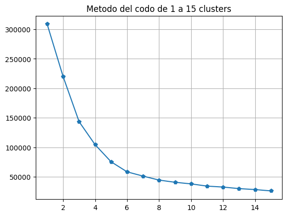

```python
import matplotlib.pyplot as plt
from sklearn.cluster import KMeans

sse = []

clusters = list(range(1, 16))
for k in clusters:
    kmeans = KMeans(n_clusters=k).fit(X)
    sse.append(kmeans.inertia_)

plt.plot(clusters, sse, marker="p")
plt.title("Metodo del codo de 1 a 15 clusters")
plt.grid(True)
plt.show()
```

**Pregunta 1:** Según el gráfico anterior (usando el método del codo), ¿Cuántos clusters propone usar para este dataset? Escoja dos opciones y justifique su elección. ¿Qué puede decir del efecto de los parámetros `n_init` y `max_iter`? (tuvo que usar valores muy altos, muy bajos, etc.)

> Respuesta: Se propone utilizar 4 y 5 clusters.

**Pregunta 2:** Genere un gráfico para cada uno de los dos `k` elegidos para tener una representación visual de los clusters, y comente lo siguiente:

- ¿Qué puede decir de los clusters generados?
- ¿Existen patrones de agrupación?

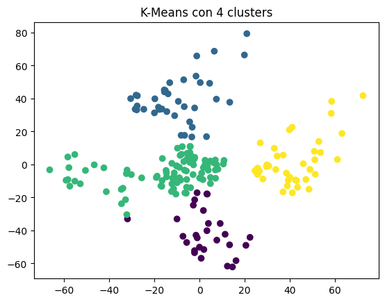

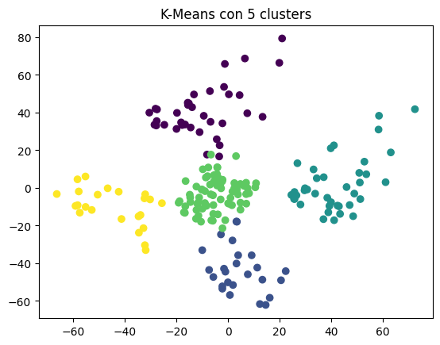

```python
# Respuesta código

for i in [4, 5]:
    kmeans = KMeans(n_clusters=i).fit(X)
    plt.scatter(X_pca[:, 0], X_pca[:, 1], c=kmeans.labels_)
    plt.title(f"K-Means con {i} clusters")
    plt.show()
```

> Podemos ver que los clusters generados se ven algo definidos en torno a un centro de masa que alcanzo a delucidar k means, en especifico en 5 se logra ver esto, el patron que se puede alcanzar a dilucidar es espacialmente en el grafico en puntos cardinales

## DBSCAN

Con DBSCAN necesitamos dos parámetros, `eps`y `min_samples`. El siguiente código permite estimar el valor `eps` usando el método de la rodilla (basado en KNN). La idea de este procedimiento es calcular la distancia promedio de cada punto a sus k vecinos más cercanos los cuales son graficados en orden ascendente. El objetivo es determinar la `rodilla`, que corresponde al valor óptimo de `eps`.

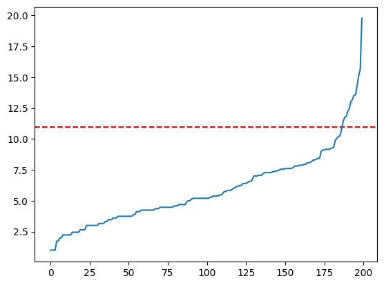

```python
from sklearn.neighbors import NearestNeighbors
import numpy as np

N = 5 #corresponde a 'min_samples'

nbrs = NearestNeighbors(n_neighbors=N).fit(X)
distances, indices = nbrs.kneighbors(X)

distances = np.sort(distances, axis=0)
distances = distances[:,1]
plt.axhline(y=11, color='r', linestyle='--') #Ajuste el valor para y
plt.plot(distances)
```

**Pregunta 3:** Utilizando el método de la rodilla, pruebe varios valores de `y`, y escoja el que usted considere el mejor `y`. Grafique los clusters usando el método DBSCAN haciendo uso del parámetro `eps` (`y`) encontrado previamente, y `min_samples=5`. Comente:

- ¿Por qué escogió el valor `y` como mejor opción?
- ¿Cuántos clusters obtuvo? Imprima los clusters obtenidos.
- ¿Qué puede decir de los clusters generados?

```
5 Clusters obtenidos
```

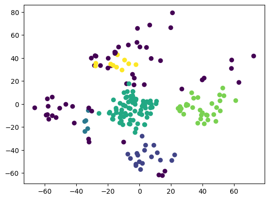

```python
# Respuesta código
from sklearn.cluster import DBSCAN
import numpy as np
dbscan = DBSCAN(eps=11, min_samples=5).fit(X)
plt.scatter(X_pca[:, 0], X_pca[:, 1], c=dbscan.labels_)
print(f"{len(np.unique(dbscan.labels_))-1} Clusters obtenidos")
```

> Lo escogimos bajo el metodo de la rodilla, y=11 se logra dilucidar bien el momento de cambio de pendiente. alcanzamos a obtener 5 clusters distintos. estos clusters a excepcion del central son bastante pobres donde el metodo dejo muchos datos como ruido.

**Pregunta 4:** ¿Cómo cambia el resultado si ahora cambia el `N` (el valor de `min_samples`)?

Juegue con distintos valores de `N`, determine el `eps` correspondiente, y describa sus observaciones.

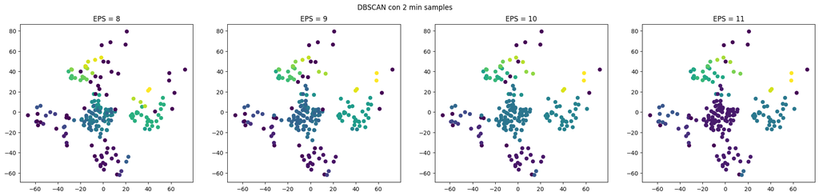

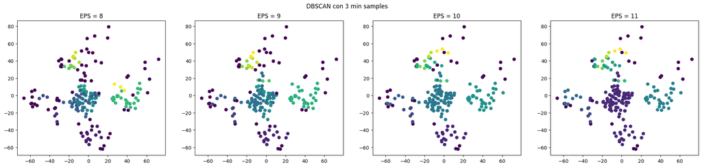

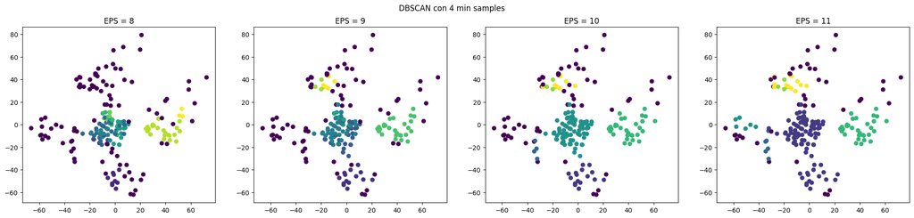

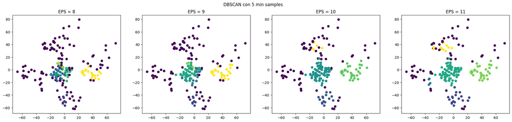

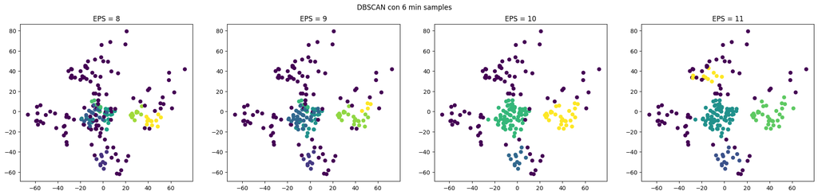

```python
#Respuesta código
for N in range(2, 7):
    axis = list()
    fig, axis = plt.subplots(1, 4, figsize=(25, 5))
    for i, ax in enumerate(axis):
        y = i+8
        dbscan_var = DBSCAN(eps=y, min_samples=N).fit(X)
        ax.scatter(X_pca[:, 0], X_pca[:, 1], c=dbscan_var.labels_)
        ax.set_title(f"EPS = {y}")

    # dbscan_var = DBSCAN(eps=11, min_samples=i).fit(X)
    # plt.scatter(X_pca[:, 0], X_pca[:, 1], c=dbscan_var.labels_)
    # plt.title(f"DBSCAN con {i} min samples")
    fig.suptitle(f"DBSCAN con {N} min samples")
    fig.show()
```

> Con min samples tiende a ir al centro de los datos mientras y comienza a descartar mas de estos en la periferia, mientras que eps le hace counter weight a este valor

## Clustering Jerárquico Aglomerativo

**Pregunta 5:** Grafique un dendograma con el método `ward` y la métrica `euclidean`. Comente: ¿"visualmente" cuántos clusters propone usar? ¿A qué altura recomendaría cortar el árbol?

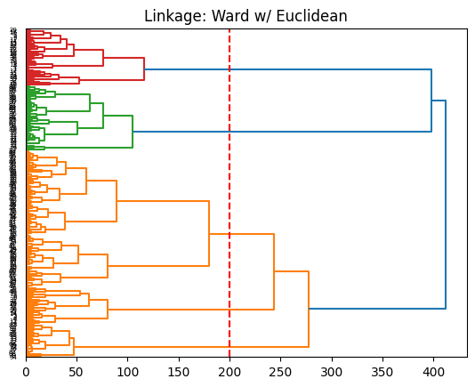

```python
#Respuesta código
from scipy.cluster.hierarchy import dendrogram, linkage

names = X["Spending Score (1-100)"]
Z   = linkage(X, 'ward', metric='euclidean')
dn  = dendrogram(Z, labels=names.tolist(), orientation='right')
plt.title("Linkage: Ward w/ Euclidean")
plt.axvline(x=200, color='r', linestyle='--')
```

> Recomendariamos cortar el arbol en x=200 debido a que encontramos 5 clusters no tan ramificados y consisos, es un buen equilibrio antes de la unificacion de todos los clusters

**Pregunta 6:** Implemente el código para asignar clusters a los datos siguiendo lo que usted propuso en la pregunta anterior y visualice los datos con su respectiva asignación. Comente lo siguiente:

- ¿Cuántos clusters obtuvo cortando a la altura que propuso en la pregunta anterior?
- ¿Qué puede decir de los clusters generados?

```
5 Clusters obtenidos
```

[figure not shown]

```python
#Respuesta código
from sklearn.cluster import AgglomerativeClustering
ward_link = AgglomerativeClustering(n_clusters=None, distance_threshold=200, linkage="ward").fit(X)
plt.scatter(X_pca[:, 0], X_pca[:, 1], c=ward_link.labels_)
plt.title("Ward Linkage cortado en 100")
print(f"{len(np.unique(ward_link.labels_))} Clusters obtenidos")
```

> Se obtuvieron 5 clusters como habiamos visto antes en el arbol, este cluster se ve bien definido, el cual ha logrado lucidar una buena forma de sus datos

## Evaluación

Para evaluar clusters existen una serie de métodos y métricas. Para este laboratorio usaremos el **Coeficiente de Silhouette**.

**Pregunta 7:** Para cada uno de los experimentos, los dos de la parte de `kmeans` en la pregunta **2**, los dos de la parte de `dbscan` en la pregunta **3** y **4 (únicamente para el mejor caso)**, y el de `clustering jerárquico` en la pregunta **6**, imprima el Silhouette score de los modelos. Adjunte código.

```python
#Respuesta código
from sklearn.metrics import silhouette_score

print("Dataset X K-Means\t", silhouette_score(X, kmeans.labels_))
print("Dataset X DBSCAN RAW\t", silhouette_score(X, dbscan.labels_))
# para DBSCAN tenermos que filtrar las labels negativas, ya que representan ruido, no otro cluster:
_filter_label = dbscan.labels_ >= 0
print("Dataset X DBSCAN FILTER\t", silhouette_score(X[_filter_label], dbscan.labels_[_filter_label]))
print("Dataset X Ward Agg\t", silhouette_score(X, ward_link.labels_))
```

```
Dataset X K-Means	 0.4402372958247734
Dataset X DBSCAN RAW	 0.15950489369586132
Dataset X DBSCAN FILTER	 0.430121882668856
Dataset X Ward Agg	 0.43997527212476695
```

**Pregunta 8:** En base a los valores del coeficiente de Silhouette obtenidos para cada método y configuración, ¿cuál considera que es el que tiene mejor resultado? Argumente su respuesta.

> Realmente, podemos ver que los distintos modos nos dieron buenos resultados en general, no obstante si tomamos a dbscan raw podemos encontrar un puntaje bastante bajo, si bien no debiesen ser contados creemos que como dejo demasiados puntos como ruido, realmente no fue tan util como lo fue K means o Agglomerative Clustering que nos entregaron clusters bien definidos. De estos ultimos tambien pensamos que si su silueta tuvo un escore algo bajo (considerando el rango 0, 1) esto debiese ser debido a la gran interseccion que se podia visualizar en los datos al torno de (0, 0)

**Pregunta 9:** ¿Qué considera que representa cada cluster en este conjunto de datos?

```python
# vamos a usar el de kmeans dado que es el que mejor resultado nos dio
X["Tipo"] = kmeans.labels_
X
```

|  | Age | Annual Income (k$) | Spending Score (1-100) | Genre_Male | Tipo |
| --- | --- | --- | --- | --- | --- |
| 0 | 19 | 15 | 39 | 1 | 4 |
| 1 | 21 | 15 | 81 | 1 | 1 |
| 2 | 20 | 16 | 6 | 0 | 4 |
| 3 | 23 | 16 | 77 | 0 | 1 |
| 4 | 31 | 17 | 40 | 0 | 4 |
| ... | ... | ... | ... | ... | ... |
| 195 | 35 | 120 | 79 | 0 | 2 |
| 196 | 45 | 126 | 28 | 0 | 0 |
| 197 | 32 | 126 | 74 | 1 | 2 |
| 198 | 32 | 137 | 18 | 1 | 0 |
| 199 | 30 | 137 | 83 | 1 | 2 |

200 rows × 5 columns

> Tipos de consumidores, segun su ingreso y tendencia al consumo